# Session 13: Multiple Regression

Mobina Pourmoshir

4/26/2024

# Simple Linear Regression

- In our previous lecture, we discussed simple linear regression analysis as a statistical method used to understand the relationship between two variables.
- It provides a linear equation that describes the relationship of one variable $y$, the dependent variable, to another variable $x$, the independent variable.
- The following are steps of the simple linear regression procedure.
  1. Describe the research question in clear unambiguous terms.
  2. Define the variables and describe the sample being used in the analysis.
  3. Verify tentatively that the two variables are linearly related.
  4. Make and inspect a residual plot.
  5. Use the `summary()` function to unpack the important information from the model object.
  6. Description, prediction, and conclusion.

# Multiple Regression

- Multiple regression is a statistical method used to understand the relationship between one dependent variable $y$ and more than one independent variables $x_1, x_2,\cdots,x_n$.
- The analysis and interpretation of multiple regression are in large part the same as they are in the case of simple linear regression.
- One of the differences between the two method is that in multiple regression, we no longer refer to the regression **line** but rather the regression **plane**, since there are always at least two independent variables.
- The multiple regression model with $k$ independent variable takes the form;
  $$y= \beta_0 + \beta_1x_1 + \beta_2x_2 +
  \cdots + + \beta_kx_k + \epsilon$$
  where
  $y$ is the dependent variable;
  $x_1, x_2,\cdots,x_k$ are the independent or predictor variables;
  $\beta_0$ is the y-intercept;
  $\beta_1, \beta_2, \cdots , \beta_k$ are the partial regression coefficients;
  $\epsilon$ is the error term.
- The estimated multiple regression equation is given by,
  $$\hat{y} = b_0 + b_1x_1 + b_2x_2 + \cdots +
  b_kx_k$$
  .

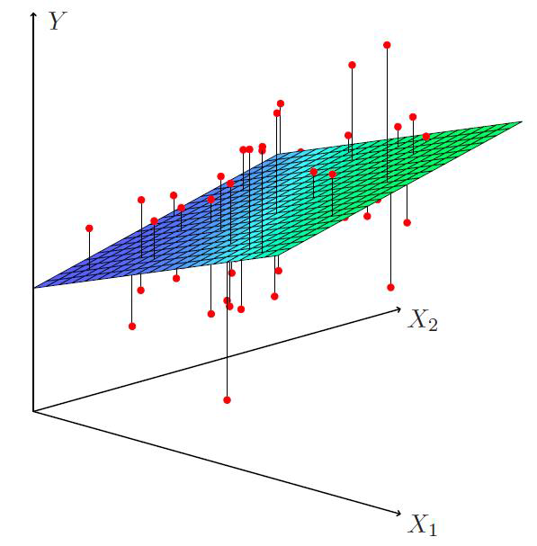

# Example

```
## 'data.frame':    18 obs. of  3 variables:
##  $ minutes   : int  558 448 228 369 534 446 390 410 252 357 ...
##  $ visits    : int  14 13 13 12 14 13 12 13 12 14 ...
##  $ kilometers: int  161 121 81 129 161 121 161 145 81 105 ...
```

# Example

- Continuing with the steps.
  3. **Verify tentatively that the two variables are linearly related.**  
     Here we construct and inspect a scatter plot. We can use the `plot()` function and do a pairwis plot. An easier way will be to use the `pairs()` function to provide all three scatter plots simultaneously.

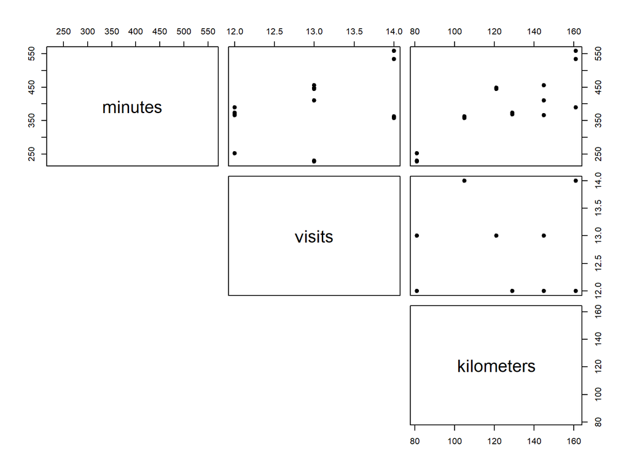

```r
pairs(brisbane, pch=19, lower.panel=NULL)
```

- The plot in the upper right-hand corner is a plot of the variable `minutes` against `kilometers` which appears to be positively related.
- The plot in the center column of the top row is a plot of the variable `minutes` against `visits`, which also appears to be positively related.
- Finally the plot in the second row of the right-hand column is a plot of the variable `visits` against `kilometers`, which appears not related in any symmetric way.
- The extent to which independent variables are related can lead to a problem in the multiple regression formulation known as **multicollinearity**.
- Multicollinearity is a condition characterizing multiple regression models when some of the independent variables are correlated with one another.
- Calculating correlation coefficients, and creating and examining scatter plots are some of the ways of checking for correlation.

```r
cor(brisbane$kilometers, brisbane$visits)
```

```
## [1] -0.03654897
```

- The correlation coefficient $r \approx -0.04$ is an indication that `visits` and `kilometers` are very weakly correlated, if they are correlated at all.

# Example

- Continuing with the steps.
  4. **Make and inspect a residual plot.**  
     We use the `lm()` to obtain the model and `plot()` with option `which=1` to obtain the residual plot. Remember our model is $y = b_0 +b_1x_1 + b_2x_2$.

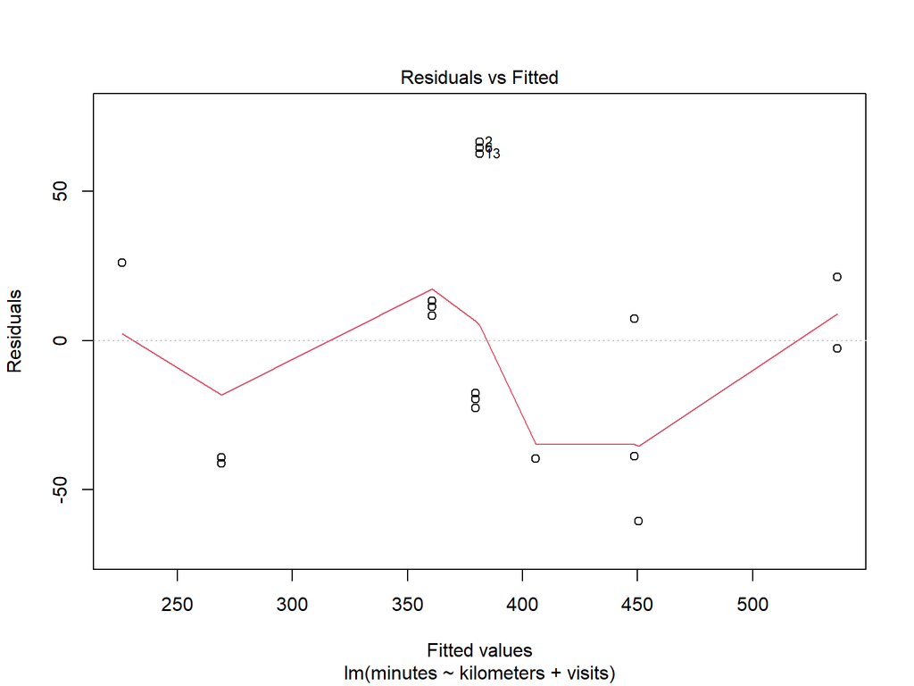

```r
mr <- lm(minutes ~ kilometers + visits, data=brisbane)
plot(mr, which=1)
```

- An inspection of the residual plot confirms;
  1. there is no evidence of a nonlinear relationships (no bends, no curves, no kinks) between the residuals and predicted values of $y$,
  2. the variance of the residual terms around $\hat{y}$ seems to be relatively constant,
  3. there appears to be no conspicuous outliers.
- Next, we observe the QQ-plot for normality.

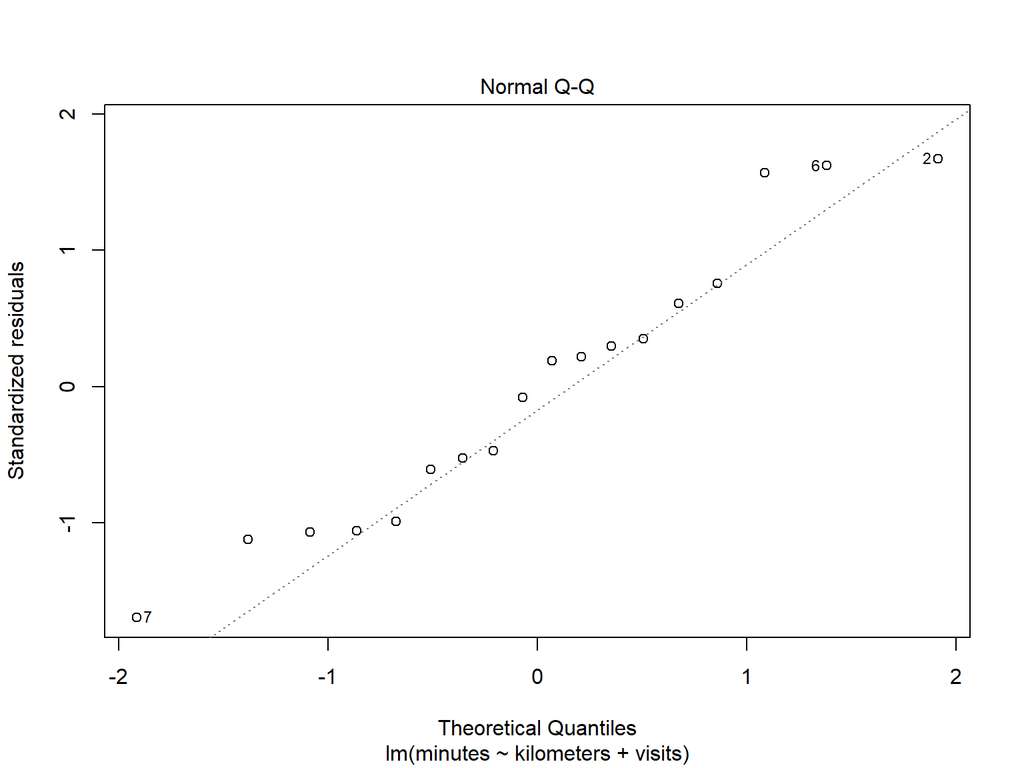

```r
plot(mr, which=2)
```

- Quite a number of point do not line on the line but are not very far from the line either. We conbclude the residuals are normally distributed.

# Example

- Continuing with the steps.
  5. **Use the `summary()` function to unpack the important information from the model object.**

```r
summary(mr)
```

```
##
## Call:
## lm(formula = minutes ~ kilometers + visits, data = brisbane)
##
## Residuals:
##     Min      1Q  Median      3Q     Max
## -60.509 -34.678   2.273  19.273  66.645
##
## Coefficients:
##              Estimate Std. Error t value Pr(>|t|)
## (Intercept) -518.7481   169.0094  -3.069  0.00779 **
## kilometers     2.8067     0.3723   7.538 1.78e-06 ***
## visits        43.1148    12.4110   3.474  0.00340 **
## ---
## Signif. codes:  0 '***' 0.001 '**' 0.01 '*' 0.05 '.' 0.1 ' ' 1
##
## Residual standard error: 41.03 on 15 degrees of freedom
## Multiple R-squared:  0.8172, Adjusted R-squared:  0.7928
## F-statistic: 33.53 on 2 and 15 DF,  p-value: 2.914e-06
```

# Practice Questions

### Example 1

This exercise uses the mtcars data set that is installed in R.

1. Use the pairs() function to create a scatter plot matrix for three variables: mpg, cyl, and wt. What can we say about the relationships between these variables?
2. Regress the dependent variable mpg on the variables cyl and wt. Write out the estimated regression equation.
3. Use the fitted() function to create the predicted dependent variables for the values of cyl and wt in the original data set. Just to check that the predictions are correct, select two observations and work out the predicted values manually.
4. Use the predict() function to create the predicted dependent variable for the following pairs of values of the independent variables: for the first pair cyl = 4 and wt = 5; for the second pair cyl = 8 and wt = 2.

```r
dat1 <- mtcars[,c("mpg","cyl","wt")]
tail(dat1,6)
```

```
##                 mpg cyl    wt
## Porsche 914-2  26.0   4 2.140
## Lotus Europa   30.4   4 1.513
## Ford Pantera L 15.8   8 3.170
## Ferrari Dino   19.7   6 2.770
## Maserati Bora  15.0   8 3.570
## Volvo 142E     21.4   4 2.780
```

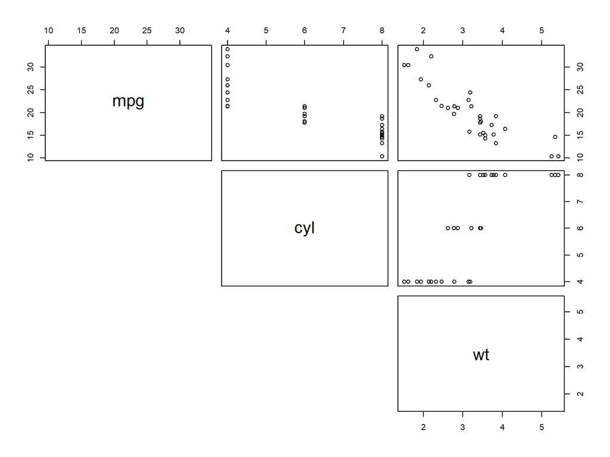

```r
pairs(dat1,lower.panel=NULL)
```

```r
mr1 <- lm(mpg ~ cyl + wt, data=dat1)
mr1
```

```
##
## Call:
## lm(formula = mpg ~ cyl + wt, data = dat1)
##
## Coefficients:
## (Intercept)          cyl           wt
##      39.686       -1.508       -3.191
```

```r
### equation yhat = 39.686 -1.508*cyl  -3.191*wt

predicted <- fitted(mr1)
tail(predicted, 2)
```

```
## Maserati Bora    Volvo 142E
##      16.23213      24.78418
```

```r
###
tail(dat1,2)[,c(2,3)]
```

```
##               cyl   wt
## Maserati Bora   8 3.57
## Volvo 142E      4 2.78
```

```r
39.686-1.508*8-3.191*3.57
```

```
## [1] 16.23013
```

```r
39.686-1.508*4-3.191*2.78
```

```
## [1] 24.78302
```

```r
### (d)
newvalues <- data.frame(cyl = c(4, 8), wt = c(5, 2))
predict(mr1, newvalues)
```

```
##        1        2
## 17.70022 21.24196
```

# Practice Questions

### Example 2

Interpret the results below and answer the following questions. Suppose we regress the dependent variable y on four independent variables $x_1, x_2, x_3, \text{and}\; x_4$. After running the regression on $n = 16$ observations, we have the following information: SSreg = 946.181 and SSres = 49.773. Please answer the following questions.

1. What is the $r^2$?
2. What is the adjusted–$r^2$? $\text{adjusted-}r^2 =r^2 - \frac{k(1-r^2)}{(n-k-1)}$

The difference between R squared and adjusted R squared value is that R squared value assumes that all the independent variables considered affect the result of the model, whereas the adjusted R squared value considers only those independent variables which actually have an effect on the performance of the model.

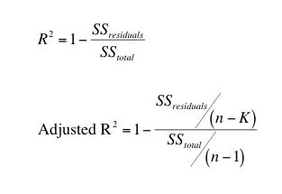

3. What is the F statistic?

A large F-statistic value proves that the regression model is effective in its explanation of the variation in the dependent variable and vice versa.

4. What is the p-value?
5. Is the overall regression model significant? Test at $\alpha= 0.05$ level of significance.

# Practice Questions

### Example 3

Consider the estimated regression equation:$\hat{y} = 3536 + 1183x_1 – 1208x_2$. Suppose the model is changed to reflect the deletion of $x_2$ and the resulting estimated simple linear equation becomes $\hat{y}= –10663 + 1386x_1$.

1. How should we interpret the meaning of the coefficient on $x_1$ in the estimated simple linear regression equation $\hat{y}= –10663 + 1386x_1$?
2. How should we interpret the meaning of the coefficient on $x_1$ in the estimated multiple regression equation $\hat{y} = 3536 + 1183x_1 – 1208x_2$?
3. Is there any evidence of multicollinearity? What might that evidence be?